# Restrict Boltzmann Machine (RBM) vs Auto Encoder (AE) vs Convolutioanl Neural Network (CNN)

## 5. RBM, AE 복원 이미지 확인

- 원본이미지 vs 복원이미지 확인

```r
par(mfrow=c(3,5), mai=c(0,0.1,0.3,0))
#원본이미지
for(n in 1:5){
  image(t(X_test[n,,])[,y_pixl:1], axes=F, col=gray((0:255)/255),main="Origianl")
}
#RBM 복원이미지
for(n in 1:5){
  image(RBM_recon[n,,][,y_pixl:1], axes=F, col=gray((0:255)/255),main="RBM")
}
#AE 복원이미지
for(n in 1:5){
  image(AE_recon[n,,][,y_pixl:1], axes=F, col=gray((0:255)/255),main="AE",col.main="purple")
}
dev.off()
```

- 복원 이미지 :

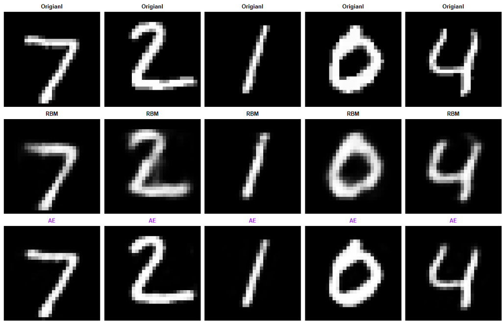

## 6.특성 추출값 + SVM 을 이용한 multi-class classification

- RBM 특성 추출 데이터 Column name 변경 및 데이터 프레임 변환

```r
colnames(RBM_hidden_node_train)<-paste("RBM_Feature_",1:100)
colnames(RBM_hidden_node_test)<-paste("RBM_Feature_",1:100)
RBM_hidden_node_train<-data.frame(RBM_hidden_node_train)
RBM_hidden_node_test<-data.frame(RBM_hidden_node_test)
```

- AE 특성 추출 데이터 Column name 변경 및 데이터 프레임 변환

```r
colnames(AE_hidden_layer_train)<-paste("AE_Feature_",1:100)
colnames(AE_hidden_layer_test)<-paste("AE_Feature_",1:100)
AE_hidden_layer_train<-data.frame(AE_hidden_layer_train)
AE_hidden_layer_test<-data.frame(AE_hidden_layer_test)
```

- SVM 모델 Fitting

```r
# svm 데이터 준비
rbm_x  <-  RBM_hidden_node_train
ae_x   <-  AE_hidden_layer_train
y      <-  as.factor(Y_train)

#RBM의 Hidden node값을 활용한 Support Vector machine fitting
svm_rbm_model <- svm(rbm_x, y, probability = TRUE)

#AE의 Hidden node값을 활용한 Support Vector machine fitting
svm_ae_model  <- svm(ae_x, y, probability = TRUE)
```

- 예측값 계산 (Test set)

```r
# RBM
svm_rbm_pred_prob <- predict(svm_rbm_model, RBM_hidden_node_test, decision.values = TRUE, probability = TRUE)
#AE
svm_ae_pred_prob <- predict(svm_ae_model, AE_hidden_layer_test, decision.values = TRUE, probability = TRUE)
```

- 예측 정확도 계산

```r
# 예측값 dataframe 생성
pred_result<-data.frame(rbm_pred=svm_rbm_pred_prob,ae_pred=svm_ae_pred_prob,true_label=Y_test)
#RBM 예측 정확도
rbm_acc<-sum(pred_result[,1]==pred_result[,3])/nrow(pred_result)
#AE 예측 정확도
svm_acc<-sum(pred_result[,2]==pred_result[,3])/nrow(pred_result)
```

## 6. CNN을 활용한 multi-class classification

- CNN 학습을 위한 데이터 준비

```r
# CNN 파라메터 설정
batch_size <- 128
num_classes <- 10
epochs <- 12

# Input image dimensions
img_rows <- 28
img_cols <- 28

# CNN 학습을 위한 MNIST 자료 차원 변경
X_train <- array_reshape(X_train, c(nrow(X_train), img_rows, img_cols, 1))
X_test <- array_reshape(X_test, c(nrow(X_test), img_rows, img_cols, 1))
input_shape <- c(img_rows, img_cols, 1)

# 변경된 차원 확인
cat('X_train_shape:', dim(X_train), '\n')
cat('X_test_shape:', dim(X_test), '\n')

# Convert class vectors to binary class matrices
Y_train <- to_categorical(Y_train, num_classes)
Y_test <- to_categorical(Y_test, num_classes)
```

- CNN 모델 정의

```r
# 모델 생성 및 구조 설정
model <- keras_model_sequential() %>%
  layer_conv_2d(filters = 32, kernel_size = c(3,3), activation = 'relu',
                input_shape = input_shape) %>%
  layer_conv_2d(filters = 64, kernel_size = c(3,3), activation = 'relu') %>%
  layer_max_pooling_2d(pool_size = c(2, 2)) %>%
  layer_dropout(rate = 0.25) %>%
  layer_flatten() %>%
  layer_dense(units = 128, activation = 'relu') %>%
  layer_dropout(rate = 0.5) %>%
  layer_dense(units = num_classes, activation = 'softmax')

# 모델 컴파일
model %>% compile(
  loss = loss_categorical_crossentropy,
  optimizer = optimizer_adadelta(),
  metrics = c('accuracy')
)

# 모델 학습
model %>% fit(
  X_train, Y_train,
  batch_size = batch_size,
  epochs = epochs,
  validation_split = 0.2
)

# 모델 평가
scores <- model %>% evaluate(
  X_test, Y_test, verbose = 0
)

#예측 정확도 계산
cnn_acc<-scores[[2]]
```

## 7. 최종 결과 확인

```r
cat('RBM Test accuracy:', rbm_acc, '\n')
cat('AE Test accuracy:', svm_acc, '\n')
cat('CNN Test accuracy:', cnn_acc, '\n')
```

- RBM Test accuracy : 0.9632
- AE Test accuracy : 0.9782
- CNN Test accuracy : 0.9911